# allhw

# Answer

**Two Methods for Solving Maximum Likelihood Estimation (MLE)**

1. **Maximization of the Log-Likelihood Function of Observational Data**
- The expression for the likelihood function of observational data is:
  $$L_o(\lambda) = \prod_{i=1}^n \left( e^{-\lambda u_i} - e^{-\lambda
  v_i} \right)$$
- The corresponding log-likelihood function is:
  $$\ln L_o(\lambda) = \sum_{i=1}^n \ln \left( e^{-\lambda u_i} -
  e^{-\lambda v_i} \right)$$
- The expression for the score function $S(\lambda)$ derived after differentiation is:
  $$S(\lambda) = \sum_{i=1}^n \frac{v_i e^{-\lambda v_i} - u_i
  e^{-\lambda u_i}}{e^{-\lambda v_i} - e^{-\lambda u_i}}$$
- MLE $\hat{\lambda}$ satisfies $S(\hat{\lambda}) = 0$.
2. **Using the EM Algorithm to Solve MLE**
- The expression for the log-likelihood function of complete data is:
  $$\ln L_c(\lambda) = n \ln \lambda - \lambda \sum_{i=1}^n X_i$$
- In the **E Step**, compute $Q(\lambda, \hat{\lambda}^{(t)})$:
  $$Q(\lambda, \hat{\lambda}^{(t)}) = n \ln \lambda - \lambda
  \sum_{i=1}^n \left[ \frac{1}{\lambda} + \frac{u_i e^{-\lambda u_i} - v_i
  e^{-\lambda v_i}}{e^{-\lambda u_i} - e^{-\lambda v_i}} \right]$$
  - In the **M Step**, update $\lambda$ by maximizing $Q(\lambda, \hat{\lambda}^{(t)})$, to obtain $\hat{\lambda}^{(t+1)}$:
    $$\hat{\lambda}^{(t+1)} = n \Bigg/ \sum_{i=1}^n \left(
    \frac{1}{\hat{\lambda}^{(t)}} + \frac{u_i e^{-\hat{\lambda}^{(t)} u_i} -
    v_i e^{-\hat{\lambda}^{(t)} v_i}}{e^{-\hat{\lambda}^{(t)} u_i} -
    e^{-\hat{\lambda}^{(t)} v_i}} \right)$$
3. **Equivalence of the Two Methods**:
- Verify that the estimators obtained by both methods are actually the same, both satisfying:
  $$\sum_{i=1}^{n} \frac{v_i e^{-\hat{\lambda} v_i} - u_i
  e^{-\hat{\lambda} u_i}}{e^{-\hat{\lambda} v_i} - e^{-\hat{\lambda} u_i}}
  = 0$$
4. **Linear Convergence Rate of the EM Algorithm**
- The EM algorithm actually defines a mapping

$$\hat{\lambda}^{(t+1)} = \phi(\hat{\lambda}^{(t)})$$
When the EM algorithm converges, it converges to a fixed point of this mapping. Hence, if $\hat{\lambda} = \phi(\hat\lambda),$ then $\hat{\lambda}^{(t+1)}-\hat{\lambda}=\phi'(\hat{\lambda}^{(t)})(\hat{\lambda}^{(t)}-\hat{\lambda})$, indicating that the EM algorithm has a linear convergence rate.

5. **Plotting the Score Function $S(\lambda)$**:
   - Using R language to plot the function graph of $S(\lambda)$, the code is as follows:

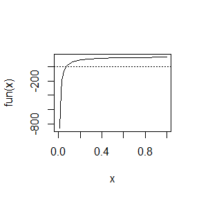

```r
U <- c(11,8,27,13,16,0,23,10,24,2)
V <- c(12,9,28,14,17,1,24,11,25,3)

fun <- function(x) {
  sapply(x, function(lambda) {
    sum((V * exp(-lambda * V) - U * exp(-lambda * U)) / (exp(-lambda * V) - exp(-lambda * U)))
  })
}

curve(fun, from = 0, to = 1)
abline(h = 0, lty = 3)
```

As the plot above, the null point is in the interval (0,0.2).

```r
mle1<- uniroot(fun, lower = 0.001, upper = 0.2)
mle1
```

```
## $root
## [1] 0.07197499
##
## $f.root
## [1] 0.002881906
##
## $iter
## [1] 8
##
## $init.it
## [1] NA
##
## $estim.prec
## [1] 6.103516e-05
```

Hence, the MLE of $\lambda$ obtained by maximizing the observed data log-likelihood function is 0.071975.

the EM algorithm is as follows

```r
rm(list = ls())
U <- c(11,8,27,13,16,0,23,10,24,2)
V <- c(12,9,28,14,17,1,24,11,25,3)

EM <- function(U,V,max.it=10000,eps=1e-8){
  n <- length(U)
  i <- 1
  theta1 <- 0.01
  theta2 <- 0.02
  while( abs(theta1 - theta2) >= eps){
    theta1 <- theta2
   fun <- function(x) {
  sapply(x, function(lambda) {
    sum((V * exp(-lambda * V) - U * exp(-lambda * U)) / (exp(-lambda * V) - exp(-lambda * U)))
  })
}
    su <- fun(theta1)
    theta2 <- n/(n/theta1 + su)
    print(round(c(theta2),9))
    if(i == max.it) break
    i <- i + 1
  }
  return(theta2)
 #return(i)
}

mle2 <- EM(U,V,max.it=10000,eps=1e-5)
```

```
## [1] 0.07195107
## [1] 0.07197349
## [1] 0.0719735
```

Hence, the MLE of $\lambda$ obtained by EM algorithm is 0.0719735.

The two estimates obtained by two method are are theoretically equivalent and the two values are numerically close.

And we have proven that the EM algorithm converges at a linear speed

# Question

In the Morra game, the set of optimal strategies are not changed if a constant is subtracted from every entry of the payoff matrix, or a positive constant is multiplied times every entry of the payoff matrix. However, the simplex algorithm may terminate at a different basic feasible point (also optimal). Compute B <- A + 2, find the solution of game B, and verify that it is one of the extreme points (11.12)–(11.15) of the original game A. Also find the value of game A and game B

# Ansewr

```r
calculate_game_solution <- function(input_matrix) {
    # Normalize the input matrix
    min_val <- min(input_matrix)
    norm_matrix <- input_matrix - min_val
    max_val <- max(norm_matrix)
    norm_matrix <- norm_matrix / max_val

    # Set up parameters for simplex method
    rows <- nrow(norm_matrix)
    cols <- ncol(norm_matrix)
    iterations <- cols^3

    # Set up for player X
    objective_x <- c(rep(0, rows), 1)
    constraint_x <- -cbind(t(norm_matrix), rep(-1, cols))
    boundary_x <- rep(0, cols)
    equality_x <- t(as.matrix(c(rep(1, rows), 0)))
    eq_boundary_x <- 1

    # Solve for player X
    solution_x <- simplex(a = objective_x, A1 = constraint_x, b1 = boundary_x, A3 = equality_x, b3 = eq_boundary_x,
                          maxi = TRUE, n.iter = iterations)

    # Set up for player Y
    objective_y <- c(rep(0, cols), 1)
    constraint_y <- cbind(norm_matrix, rep(-1, rows))
    boundary_y <- rep(0, rows)
    equality_y <- t(as.matrix(c(rep(1, cols), 0)))
    eq_boundary_y <- 1

    # Solve for player Y
    solution_y <- simplex(a = objective_y, A1 = constraint_y, b1 = boundary_y, A3 = equality_y, b3 = eq_boundary_y,
                          maxi = FALSE, n.iter = iterations)

    # Construct the final solution
    final_solution <- list(
        NormalizedMatrix = norm_matrix * max_val + min_val,
        StrategyX = solution_x$soln[1:rows],
        StrategyY = solution_y$soln[1:cols],
        GameValue = solution_x$soln[rows + 1] * max_val + min_val
    )

    return(final_solution)
}

# Sample data and library call
game_matrix <- matrix(c(0, -2, -2, 3, 0, 0, 4, 0, 0, 2, 0, 0, 0,
                        -3, -3, 4, 0, 0, 2, 0, 0, 3, 0, 0, 0, -4, -4, -3,
                        0, -3, 0, 4, 0, 0, 5, 0, 0, 3, 0, -4, 0, -4, 0, 5,
                        0, 0, 3, 0, 0, 4, 0, -5, 0, -5, -4, -4, 0, 0, 0,
                        5, 0, 0, 6, 0, 0, 4, -5, -5, 0, 0, 0, 6, 0, 0, 4,
                        0, 0, 5, -6, -6, 0), 9, 9)

library(boot)
adjusted_matrix <- game_matrix + 2
solution <- calculate_game_solution(adjusted_matrix)
print(solution$GameValue)
```

```
## x10
##   2
```

```r
print(round(cbind(solution$StrategyX, solution$StrategyY), 7))
```

```
##         [,1]      [,2]
## x1 0.0000000 0.0000000
## x2 0.0000000 0.0000000
## x3 0.4098361 0.4098361
## x4 0.0000000 0.0000000
## x5 0.3278689 0.3278689
## x6 0.0000000 0.0000000
## x7 0.2622951 0.2622951
## x8 0.0000000 0.0000000
## x9 0.0000000 0.0000000
```

```r
print(round(solution$StrategyX * 61, 7))
```

```
## x1 x2 x3 x4 x5 x6 x7 x8 x9
##  0  0 25  0 20  0 16  0  0
```

(0, 0, 5/12, 0, 4/12, 0, 3/12,0, 0), (11.12) (0, 0, 16/37, 0, 12/37, 0, 9/37, 0, 0), (11.13) (0, 0, 20/47, 0, 15/47, 0, 12/47, 0,0), (11.14) (0, 0, 25/61, 0, 20/61, 0, 16/61, 0,0). (11.15)

The game’s value is v=2 with the original’s value is v=0, and the simplex algorithm concludes at the extremal point presented in (11.15). Back to the Directory

# Homework9

# Question 2.1.3 EX4

Why do you need to use unlist() to convert a list to an atomic vector? Why doesn’t as.vector() work

# Answer

The unlist() is specifically designed to flatten a list into an atomic vector. as.vector() is used to convert an object into a specific vector

```r
require(graphics)
# create a list
pts <- list(x = cars[,1], y = cars[,2])
```

```r
vec_pts1 <- unlist(pts)
is(vec_pts1)
```

```
## [1] "numeric" "vector"
```

```r
vec_pts2 <- as.vector(pts)
is(vec_pts2)
```

```
## [1] "list"   "vector"
```

# Question 2.3.1 EX 1

What does dim() return when applied to a vector?

# Answer

creat a vector x ,then apply the dim() to x;

```r
x <- c(a = 1, b = 2)
is.vector(x)
```

```
## [1] TRUE
```

```r
dim(x)
```

[output not shown]

dim() return NULL when applied to a vector?

# Question 2.3.1 EX 2

If is.matrix(x) is TRUE, what will is.array(x) return?

# Answer

```r
m <- as.matrix(1:10)
is.matrix(m)
```

```
## [1] TRUE
```

```r
is.array(m)
```

```
## [1] TRUE
```

```r
mdat <- matrix(c(1,2,3, 11,12,13), nrow = 2, ncol = 3, byrow = TRUE,
               dimnames = list(c("row1", "row2"),
                               c("C.1", "C.2", "C.3")))
```

```r
is.matrix(mdat)
```

```
## [1] TRUE
```

```r
is.array(mdat)
```

```
## [1] TRUE
```

# Question 2.4.5 EX 2

What does as.matrix() do when applied to a data frame with columns of different types?

# Answer

```r
L3 <- LETTERS[1:3]
char <- sample(L3, 10, replace = TRUE)
d <- data.frame(x = 1, y = 1:10, char = char)
d
```

```
##    x  y char
## 1  1  1    B
## 2  1  2    C
## 3  1  3    A
## 4  1  4    A
## 5  1  5    C
## 6  1  6    B
## 7  1  7    B
## 8  1  8    A
## 9  1  9    B
## 10 1 10    A
```

```r
d_asmtrix <- as.matrix(d)
```

```r
df <- data.frame(
  Numeric = c(1, 2, 3, 4, 5),
  Character = as.character(c('a', 'b', 'c', 'd', 'e')),
  Boolean = c(TRUE, FALSE, TRUE, FALSE, TRUE),
  Factor = factor(c('apple', 'banana', 'orange', 'apple', 'banana'))
)
df
```

```
##   Numeric Character Boolean Factor
## 1       1         a    TRUE  apple
## 2       2         b   FALSE banana
## 3       3         c    TRUE orange
## 4       4         d   FALSE  apple
## 5       5         e    TRUE banana
```

```r
df_asmtrix <- as.matrix(df)
```

```r
class(d[,2])
```

```
## [1] "integer"
```

```r
class(df[,3])
```

```
## [1] "logical"
```

```r
class(d_asmtrix[,2])
```

```
## [1] "character"
```

```r
class(df_asmtrix[,3])
```

```
## [1] "character"
```

# Question 2.4.5 EX 3

Can you have a data frame with 0 rows? What about 0 columns?

# Answer

```r
d2 <- data.frame(x = 1, y = 1)
d2
```

```
##   x y
## 1 1 1
```

```r
d2 <- d2[-1,]
d2
```

```
## [1] x y
## <0 rows> (or 0-length row.names)
```

here we have a data frame with 0 rows. 0 rows dataframe is often the result of subsetting operations where no rows meet the criteria.

# Question P204 EX 2

The function below scales a vector so it falls in the range [0, 1]. How would you apply it to every column of a data frame? How would you apply it to every numeric column in a data frame? scale01 <- function(x) { rng <- range(x, na.rm = TRUE) (x - rng[1]) / (rng[2] - rng[1]) } # Answer

apply it to every column of a data frame

```r
scale01 <- function(x) {
rng <- range(x, na.rm = TRUE)
(x - rng[1]) / (rng[2] - rng[1])
}
```

```r
df<-data.frame(x=c(1,2,3,4,5),y=c(7,3,9,2,6),z=as.character(c('a', 'b', 'c', 'd', 'e')))
#df_scaled <- data.frame(lapply(df, scale01))
#df_scaled
```

cause errors if the columns are not numeric;

apply it to every numeric column in a data frame: first identify which columns are numeric and then apply the function only to those columns.

```r
numeric_cols <- sapply(df, is.numeric)
df[, numeric_cols] <- lapply(df[, numeric_cols], scale01)
df
```

```
##      x         y z
## 1 0.00 0.7142857 a
## 2 0.25 0.1428571 b
## 3 0.50 1.0000000 c
## 4 0.75 0.0000000 d
## 5 1.00 0.5714286 e
```

# Question P213 EX 1

Use vapply() to: a) Compute the standard deviation of every column in a numeric data frame. b) Compute the standard deviation of every numeric column in a mixed data frame. (Hint: you’ll need to use vapply() twice.)

# Answer

```r
df <- data.frame(x=c(1,2,3,4),y=c(5,6,7,8))
vapply(df, sd, numeric(1))
```

```
##        x        y
## 1.290994 1.290994
```

2. first identifies the numeric columns in the data frame using vapply() with the is_numeric function , then calculates the sd for each of those numeric columns using vapply() with the sd function

```r
df2<- data.frame(x = c(1,6,5,2,10),y = c(4,3,8,7,9),z = as.character(c('a', 'b', 'c', 'd', 'e')))
num_cols <- vapply(df2,is.numeric,logical(1))
vapply(df2[num_cols], sd, numeric(1))
```

```
##        x        y
## 3.563706 2.588436
```

# Question EX 9.8

This example appears in [40]. Consider the bivariate density
$$f(x, y) \propto C^x_ny^{x+a+1}(1-y)^{n-x+b-1} , x
= 0, 1, . . . , n, 0 ≤ y ≤ 1.$$
It can be shown (see e.g. [23]) that for fixed a, b, n, the conditional distributions are Binomial(n, y) and Beta(x+ a, n − x+ b). Use the Gibbs sampler to generate a chain with target joint density f(x, y). (Hint: Refer to the first example of Case studies section) • Write an R function. • Write an Rcpp function. • Compare the computation time of the two functions with the function “microbenchmark” # Answer

Write an R function

```r
gibbs_sampler_R <- function(n, a, b, num_iterations) {
  x <- numeric(num_iterations)
  y <- numeric(num_iterations)
  y[1] <- runif(1)  # Initial value for y

  for (i in 2:num_iterations) {
    x[i] <- rbinom(1, n, y[i-1])
    y[i] <- rbeta(1, x[i] + a, n - x[i] + b)
  }
  return(data.frame(x, y))
}
```

Write an Rcpp function.

```r
library(Rcpp)
library(microbenchmark)
cppFunction('
  DataFrame gibbs_sampler_Rcpp(int n, double a, double b, int num_iterations) {
    NumericVector x(num_iterations);
    NumericVector y(num_iterations);
    y[0] = R::runif(0, 1);  // Initial value for y

    for(int i = 1; i < num_iterations; i++) {
      x[i] = R::rbinom(n, y[i-1]);
      y[i] = R::rbeta(x[i] + a, n - x[i] + b);
    }
    return DataFrame::create(Named("x")=x, Named("y")=y);
  }
')
```

Compare the computation time of the two functions with the function “microbenchmark”

```r
# Define parameters
n <- 100  # Set your desired values for n, a, b, and num_iterations
a <- 2
b <- 3
num_iterations <- 10000

ts <- microbenchmark(R=gibbs_sampler_R(n, a, b, num_iterations),Rcpp=gibbs_sampler_Rcpp(n, a, b, num_iterations),times=10)
summary(ts)
```

```
##   expr     min      lq     mean   median      uq     max neval
## 1    R 48.3291 51.7307 62.64946 59.98215 70.9078 86.3584    10
## 2 Rcpp  3.4496  4.0428  7.62529  4.91290 14.3681 15.3421    10
```

The average execution time of the Rcpp/C++implementation (gibbs_sampler_cpp) is significantly lower than that of the R implementation (gibbs_sampler_R), indicating that the C++implementation is faster.

Back to the Directory

```r
# all packages used
# [1] "library(knitr)"
#[2] "library(ggplot2)"
#[3] "library(DAAG)"
#[4] "library(boot)"
#[5] "library(bootstrap)"
#[6] "library(coda)"
#[7] "library(dplyr)"
#[8] "library(stats)"
#[9] "require(graphics)"
#[10] "library(Rcpp)"
#[11] "library(microbenchmark)"
```